# 3.modelling (exercises)

# 3. BUILD VARIOUS MODELS USING WORKFLOW

```r
library("nnet")
library("NeuralNetTools")
library("vip")
library("tidymodels")
library("tidyverse")
```

## 3.1. LOOK AT DATA

[no exercises]

## 3.2. SPLIT DATA

[no exercises]

## 3.3. CREATE WORKFLOW AND FIT MODEL 1

a) Considering the following split data set and tidymodel recipe, create the respective workflow and fit a simple glm model. Use a ROC curve and the AUC to evaluate your model.

```r
hotels <-
  read_csv("https://tidymodels.org/start/case-study/hotels.csv") |>
  mutate(across(where(is.character), as.factor))
set.seed(123)
splits      <- initial_split(hotels, strata = children, prop = 0.75)
hotel_other <- training(splits)
hotel_test  <- testing(splits)
set.seed(234)
val_set <- validation_split(hotel_other, strata = children, prop = 0.80)
holidays <- c("AllSouls", "AshWednesday", "ChristmasEve", "Easter",
              "ChristmasDay", "GoodFriday", "NewYearsDay", "PalmSunday")
lr_recipe <-
  recipe(children ~ ., data = hotel_other) |>
  step_date(arrival_date) |>
  step_holiday(arrival_date, holidays = holidays) |>
  step_rm(arrival_date) |>
  step_dummy(all_nominal_predictors()) |>
  step_zv(all_predictors()) |>
  step_normalize(all_predictors())
```

```r
hotels <-
  read_csv("https://tidymodels.org/start/case-study/hotels.csv") |>
  mutate(across(where(is.character), as.factor))
set.seed(123)
splits      <- initial_split(hotels, strata = children, prop = 0.75)
hotel_other <- training(splits)
hotel_test  <- testing(splits)

holidays <- c("AllSouls", "AshWednesday", "ChristmasEve", "Easter",
              "ChristmasDay", "GoodFriday", "NewYearsDay", "PalmSunday")

lr_recipe <-
  recipe(children ~ ., data = hotel_other) |>
  step_date(arrival_date) |>
  step_holiday(arrival_date, holidays = holidays) |>
  step_rm(arrival_date) |>
  step_dummy(all_nominal_predictors()) |>
  step_zv(all_predictors()) |>
  step_normalize(all_predictors())

lr_mod <-
  logistic_reg() |>
  set_engine("glm")

lr_workflow <-
  workflow() |>
  add_model(lr_mod) |>
  add_recipe(lr_recipe)

t1 <- Sys.time()
lr_res <-
  lr_workflow |>
  fit(data = hotel_other)
Sys.time() - t1
```

```
## Time difference of 32.56325 secs
```

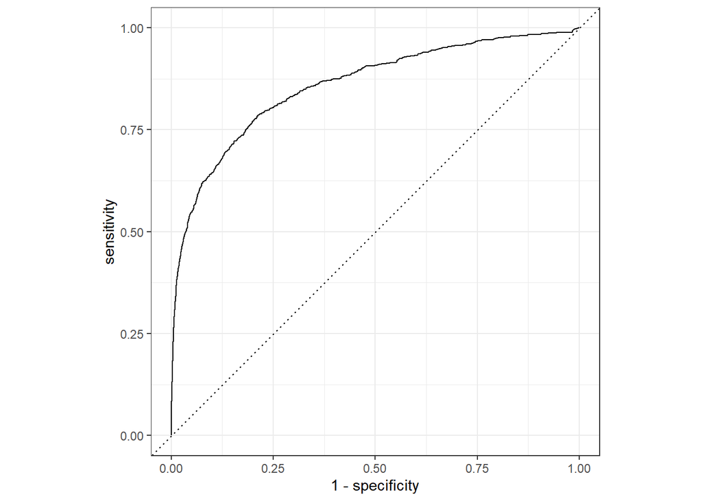

```r
lr_aug <- augment(lr_res, new_data = hotel_test)

lr_aug |> roc_curve(children, .pred_children) |> autoplot()
```

```r
lr_aug |> roc_auc(truth = children, .pred_children)
```

```
## # A tibble: 1 × 3
##   .metric .estimator .estimate
##   <chr>   <chr>          <dbl>
## 1 roc_auc binary         0.858
```

## 3.4. CREATE WORKFLOW AND FIT MODEL 2

a) Replace the glm model used above with a neural network model. Consider function mlp() with engine “nnet” and mode “classification”. For the hyper parameters, set hidden_units = 1 and penalty = tune(). Use the same recipe as before. To tune the model set a grid with 10 points and use the following data split. Choose the best model and evaluated with a ROC curve and the AUC. How confident are you about the tuning?.

```r
set.seed(234)
val_set <- validation_split(hotel_other, strata = children, prop = 0.80)
```

```r
set.seed(234)
val_set <- validation_split(hotel_other, strata = children, prop = 0.80)

cores <- parallel::detectCores()
nn_mod <-
  mlp(
    hidden_units = 1, #hidden units of the neural network
    penalty = tune(), #amount of regularization
  ) |>
  set_engine("nnet", num.threads = cores) |>
  set_mode("classification")

nn_workflow <-
  workflow() |>
  add_model(nn_mod) |>
  add_recipe(lr_recipe)

t1 <- Sys.time()
set.seed(345)
nn_res <-
  nn_workflow |>
  tune_grid(
    val_set,
    grid = 10,
    control = control_grid(save_pred = TRUE),
    metrics = metric_set(roc_auc)
  )
Sys.time() - t1
```

```
## Time difference of 2.227265 mins
```

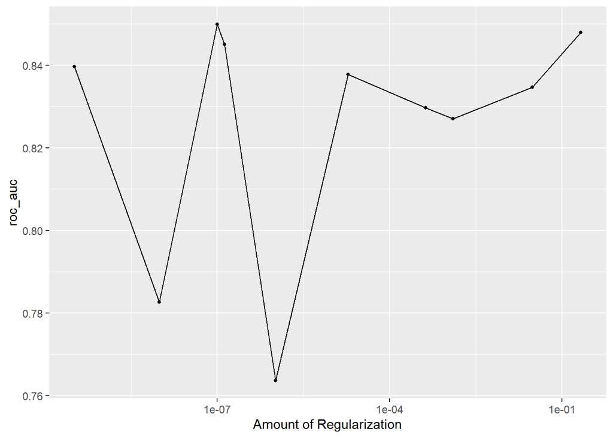

```r
autoplot(nn_res)
```

```r
nn_res |>
  show_best(metric = "roc_auc", n = 5)
```

```
## # A tibble: 5 × 7
##    penalty .metric .estimator  mean     n std_err .config
##      <dbl> <chr>   <chr>      <dbl> <int>   <dbl> <chr>
## 1 9.92e- 8 roc_auc binary     0.850     1      NA Preprocessor1_Model01
## 2 2.12e- 1 roc_auc binary     0.848     1      NA Preprocessor1_Model07
## 3 1.33e- 7 roc_auc binary     0.845     1      NA Preprocessor1_Model04
## 4 3.26e-10 roc_auc binary     0.840     1      NA Preprocessor1_Model06
## 5 1.90e- 5 roc_auc binary     0.838     1      NA Preprocessor1_Model05
```

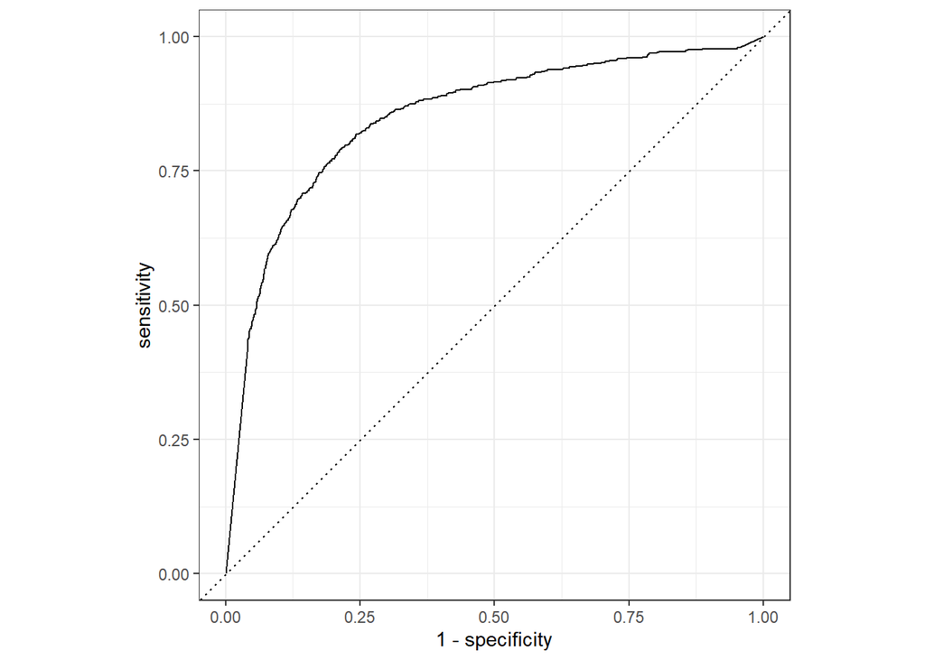

```r
# The best values of the parameter seem to be rather random, providing little
# confidence about the tuning.

nn_best <-
  nn_res |>
  select_best(metric = "roc_auc")

nn_pred <-
  nn_res |>
  collect_predictions(parameters = nn_best)

nn_pred |>
  roc_curve(children, .pred_children) |>
  autoplot()
```

```r
nn_pred |> roc_auc(children, .pred_children)
```

```
## # A tibble: 1 × 3
##   .metric .estimator .estimate
##   <chr>   <chr>          <dbl>
## 1 roc_auc binary         0.850
```

## 3.5. EVALUATE MODEL

a) Choose the best neural network model and evaluated it using the test data created before. For the evaluation, consider the ROC curve and the AUC. Finish the analysis by plotting the most important features (i.e. predictors) of the final model. Set the importance parameter of the engine to “impurity”.

```r
last_nn_mod <-
  mlp(hidden_units = 1, penalty = nn_best$penalty) |>
  set_engine("nnet", num.threads = cores, importance = "impurity") |>
  set_mode("classification")

last_nn_workflow <-
  nn_workflow |>
  update_model(last_nn_mod)

t1 <- Sys.time()
set.seed(345)
last_nn_fit <-
  last_nn_workflow |>
  last_fit(split = splits)
Sys.time() - t1
```

```
## Time difference of 16.73268 secs
```

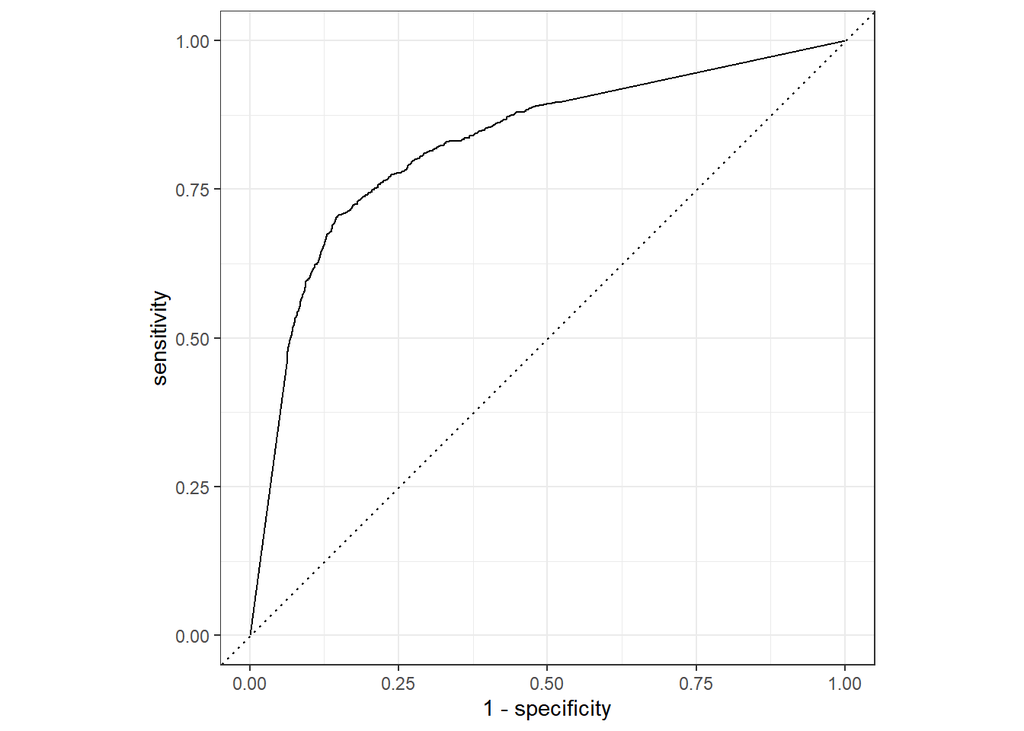

```r
last_nn_fit |>
  collect_predictions() |>
  roc_curve(children, .pred_children) |>
  autoplot()
```

```r
last_nn_fit |>
  collect_metrics()
```

```
## # A tibble: 2 × 4
##   .metric  .estimator .estimate .config
##   <chr>    <chr>          <dbl> <chr>
## 1 accuracy binary         0.919 Preprocessor1_Model1
## 2 roc_auc  binary         0.826 Preprocessor1_Model1
```

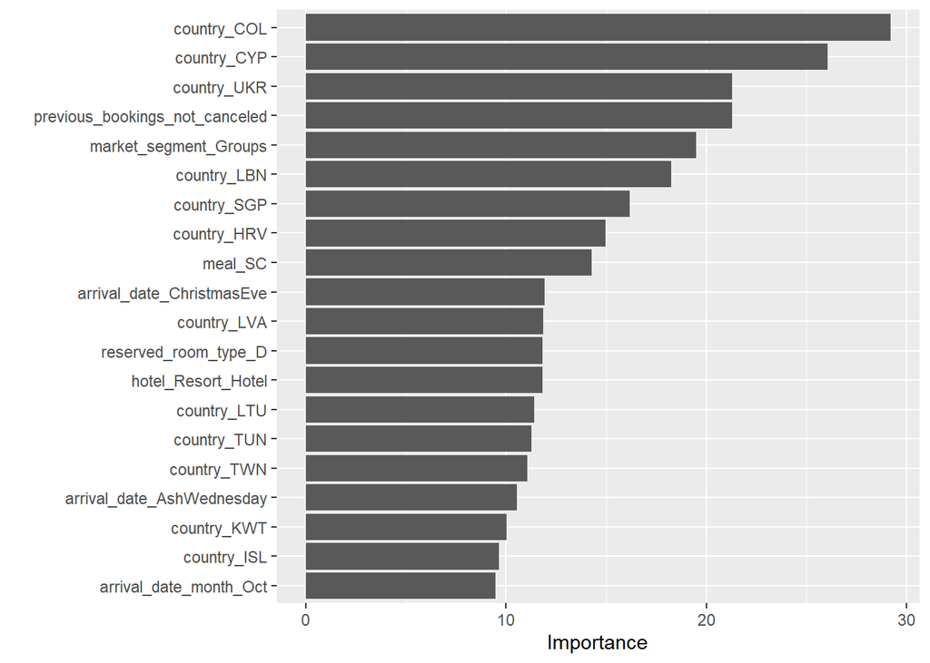

```r
last_nn_fit |>
  extract_fit_parsnip() |>
  vip(num_features = 20)
```